# Statistical Inference Course Project

Dylan Hazlett

Thank you for reviewing my final report for the Statistical Inference Course. In Part 1, we will simulate a collection exponential variables, then compare the sample’s summary statistics to their theoretical values and distribution. In Part 2, we will analyze the differences in tooth-growth among varying doses and delivery methods of Vitamin C using the ToothGrowth dataset in R.

### Part 1: Simulation of Expontentially Distributed Variables

```r
mns = NULL
vars = NULL
for (i in 1 : 1000) {
  mns = c(mns, mean(rexp(40, .2)))
}
```

The above block of code simulates the distribution of averages of 40 exponentials with lambda value .2, 1000 times. After initializing ‘mns’ to record the means, a for loop runs the exponential distribution expressions and gathers each mean 1000 times. The output is an array of 1000 independently sampled means.

```
## [1] "Using the mean() function on the array, mns, we can calculate the average Sample Mean: 5.02528893363976"
```

Theoretically, and with enough simulations, this value will converage to the mean of the exponential distribution, 1/lambda or 5 since lambda = .2.

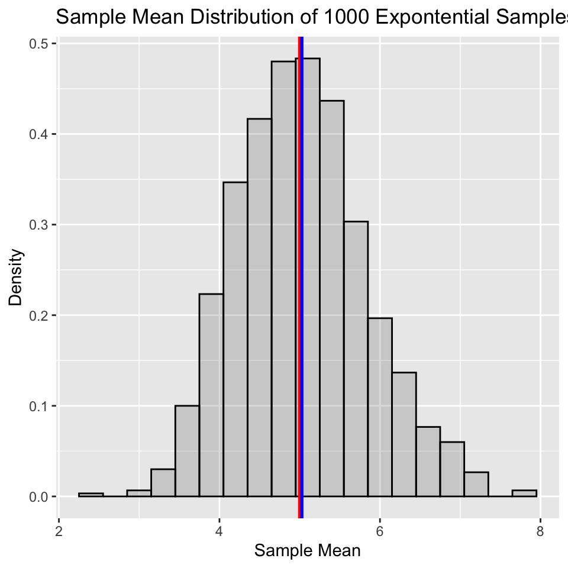

This figure shows the distribution of the 1000 sample means with two vertical lines, the average sample mean in blue and the theoretical mean in red. The two may appear to be touching on the chart due to how close they are in value.

```
## [1] "Using the var() function, we can calculate that the Sample Variance is 0.651939499915466"
```

To compare the sample variance to its theoretical value for the exponential distribution, we use the following formula given that n equals 40 and sigma equals the standard deviation, given that the standard deviation of the exponential distribution is 1/lambda where lambda equals 0.2. $\bar Var = \sigma^2 / n$

```
## [1] "The Theoretical Variance for 40 exponential variables where lambda equal 0.2 is 0.625"
```

Given infinite simulations, the sample variance will converge to this value of 0.625.

This simulation is an example of the Central Limit Theorem, where the mean samples resulting from the simulations are normally distributed around the theoretical mean.

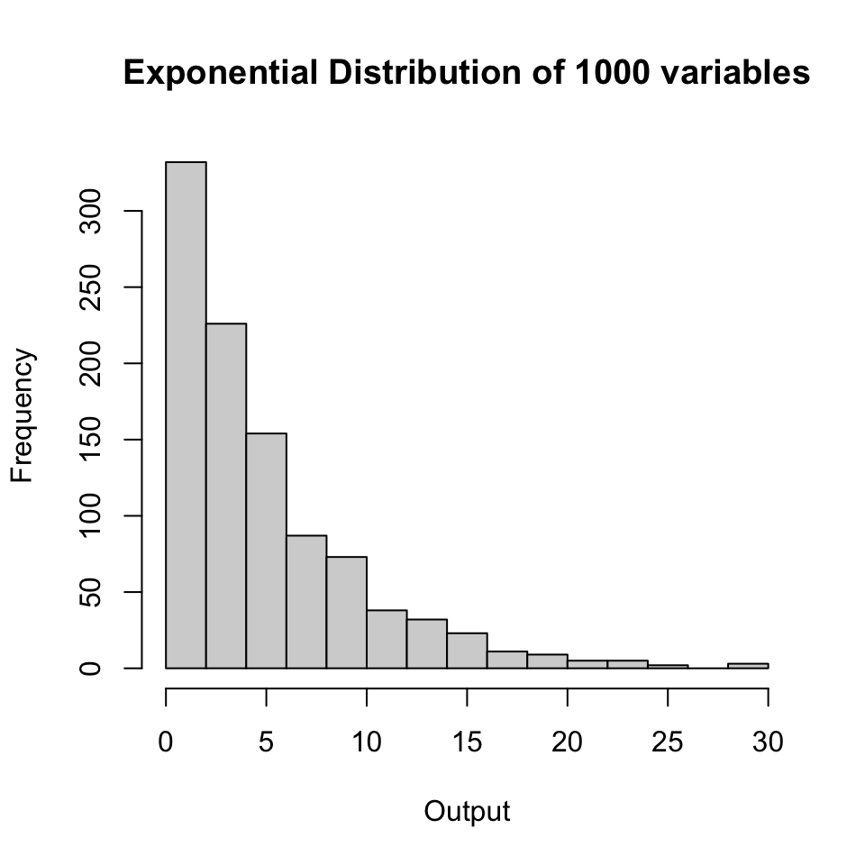

The exponential distribution is of course not normally distributed; but, after taking 1000 random and independent samples of the mean of this distrubtion, we get the below distribution that appears to be a normal Guassian distribution of samples.

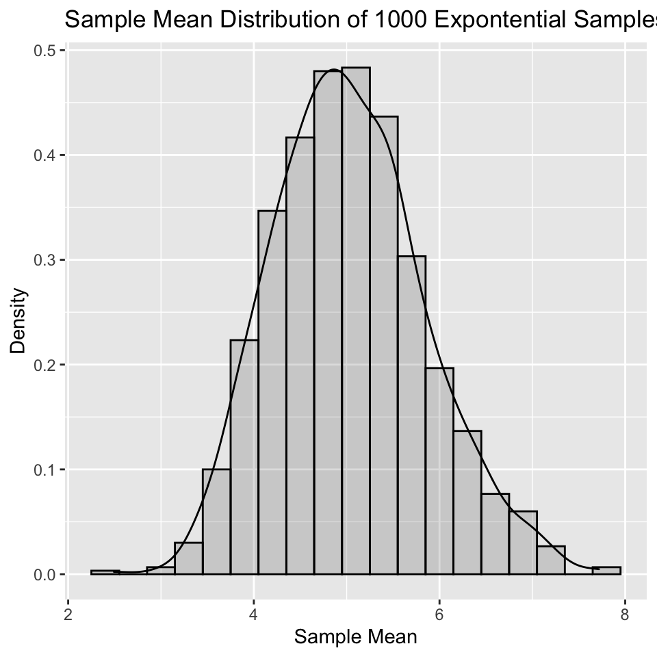

Although the right tail of this distribution stretches further from the mean than that of the right, that is expected due to the nature of the exponential distribution stretching to infinity on the x-axis. We accept this drawback and conclude that the distribution is approximately normal. Using the central limit theorem, we assume iid, meaning our exponential variables were sampled randomly and independently of one another. We also assume that the sample size of 40 independent variable was sufficiently large, which is a safe assumption due to the resulting distribution chart.

## Part 2: ToothGrowth

Now, for Part 2, lets load and explore the ToothGrowth dataset in R.

```r
library(dplyr)
ToothGrowth%>% group_by(dose, supp)%>%summarise(mean(len), n())
```

| dose | supp | mean(len) | n() |
| --- | --- | --- | --- |
| 0.5 | OJ | 13.23 | 10 |
| 0.5 | VC | 7.98 | 10 |
| 1.0 | OJ | 22.70 | 10 |
| 1.0 | VC | 16.77 | 10 |
| 2.0 | OJ | 26.06 | 10 |
| 2.0 | VC | 26.14 | 10 |

The ToothGrowth dataset has 60 data entries of tooth length (len), dosage mg/day (dos), and supplement type (supp). With two supplements (VC or OJ) and 3 dosage levels (0.5, 1, and 2 mg/day), there are 10 data entries to each of the 6 group combinations of dosage and suplement. Since these entries are not paired, any comparison between these groups will use the mean, which is provided to give a rough expectation of what groups may have significantly different lengths. It apprears that lower doses contribute to less tooth lenght growth, as well as more growth with the OJ supplement vs the VC supplement for lower doses.

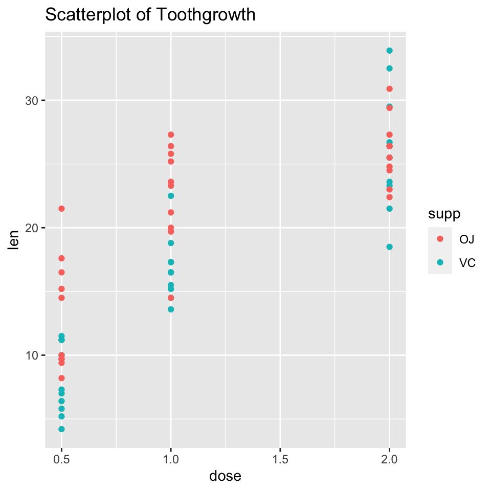

Here is a visual comparison of all of the length data points split by dosage on the x-axis and supplement for color. We can see that, at a dosage of 2 mg/day, there is little difference in the distribution of length among supplements. We will keep this and our earlier hypothesis in mind as we now construct confidence intervals for all 6 groups.

```r
ToothGrowth%>% group_by(dose, supp)%>%summarise(mean(len),lower_int = mean(len)-(qt(.975,9)*sd(len)/ sqrt(n())), upper_int = mean(len)+(qt(.975,9)*sd(len)/ sqrt(n())))
```

| dose | supp | mean(len) | lower_int | upper_int |
| --- | --- | --- | --- | --- |
| 0.5 | OJ | 13.23 | 10.039717 | 16.420283 |
| 0.5 | VC | 7.98 | 6.015176 | 9.944824 |
| 1.0 | OJ | 22.70 | 19.902273 | 25.497727 |
| 1.0 | VC | 16.77 | 14.970657 | 18.569343 |
| 2.0 | OJ | 26.06 | 24.160686 | 27.959314 |
| 2.0 | VC | 26.14 | 22.707910 | 29.572090 |

Lastly, let’s run a t test between supplements on all subjects with equal variances set to False: Given OJ, Var(len) = 43.63 Given VC, Var(len) = 68.33 Note: This test cannot be preformed with dosage as there are more than two groups.

```r
t.test(len ~ supp, paired = FALSE, var.equal = FALSE, data = ToothGrowth)
```

```
##
##  Welch Two Sample t-test
##
## data:  len by supp
## t = 1.9153, df = 55.309, p-value = 0.06063
## alternative hypothesis: true difference in means between group OJ and group VC is not equal to 0
## 95 percent confidence interval:
##  -0.1710156  7.5710156
## sample estimates:
## mean in group OJ mean in group VC
##         20.66333         16.96333
```

Using the t test result, we cannot conclude with 95% confidence that tooth growth is different between supplement groups.

To use the t confidence intervals and the t test we assumes that the data are iid and have a roughly symmetrical distribution.